# MSB.102: Biostatistics and Experimental Design: Example Final Exam

Adam Clark

2025-03-08

Below is an example final exam question. The real test will have three questions like these - you will have ca. 90 minutes to complete the exam (in class on the last of the Clark sessions).

Analyse the following datasets using ordinary least squares (OLS) mixed effects (ME) linear regressions. Then use the results of your analyses to answer the following questions. Record your answers and corresponding R commands on the answer sheet (with informative comments!) and submit them over the Moodle site before the end of class. Please make your answers *short* - just a few words and lines of code per question is enough.

You may use notes, internet searches, AI, etc. to help you with the assignments - however, you must answer the questions yourself (i.e. no working together with other students).

## Question 1: Plant Biodiversity Experiment (12 points total)

You have been asked by your supervisor to tests for relationships between biodiversity and productivity in a grassland plant experiment. Each of 30 plots have been planted with mixtures of 1, 2, 4, 8, or 16 grassland plant species, and the corresponding dry aboveground biomass has been measured at the end of the growing season for the past 3 years:

```r
bdat = read.csv("dEx_biodiversity.csv")
head(bdat)
```

```
##   plot_id year biodiversity productivity
## 1       1    1            1     13.94024
## 2       2    1            8     25.04064
## 3       3    1            2     23.87935
## 4       4    1            2     13.89339
## 5       5    1            4     25.68341
## 6       6    1            2     26.12128
```

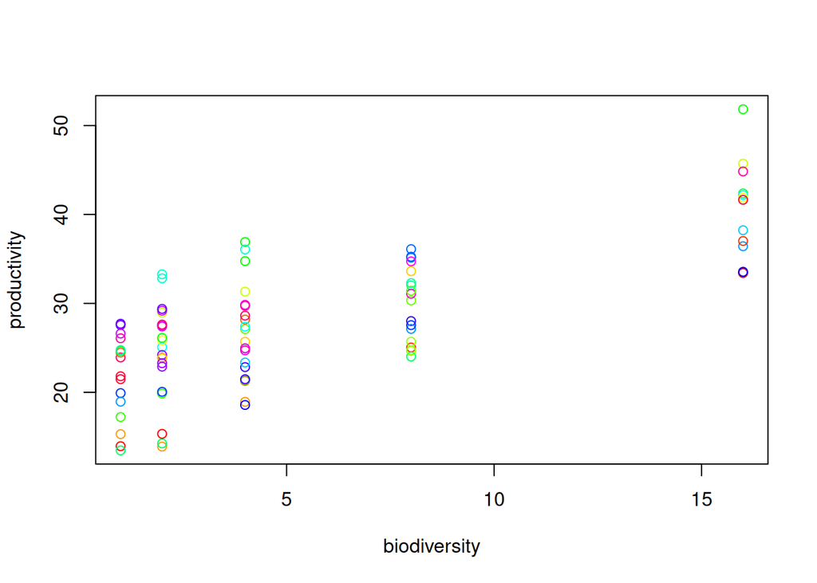

```r
plot(productivity ~ biodiversity, bdat, col = rainbow(30)[bdat$plot_id])
```

Note: each plot is shown in a different color.

### Question 1.1: 2 points

Fit a simple linear model to the data using the following command:

```r
require(nlme)
  mod1.0 = gls(productivity ~ biodiversity, data = bdat)
```

What are the slope and intercept for this model? Are they significant? What do these terms tell us about the relationship between biomass and productivity in this experiment?

### Question 1.2: 3 points

Now, update the model described above to include a random intercept term grouped by plot_id, using the commands in the nlme package.

What is the resulting plot-level variability (can be expressed as variance or standard deviation) for the regression? How does it compare to the residual (unexplained) variability?

### Question 1.3: 3 points

Compare the two models via ANOVA. Which model provides a better fit for the data? Hint: remember that you might need to refit the models with a different algorithm before comparing them.

### Question 1.4: 2 points

Make a histogram showing the plot-level random effects for the regression in Question 1.2 (you only need to upload the code for doing so, not the image).

### Question 1.5: 2 points

What kind of statistical distribution do these random effects follow? What are the mean and standard deviation of the distribution?